# R Notebook

```r
library(tidyverse)
library(here)
library(ggplot2)

#Incidence is across 2013 through 2017 and Mortality is across 2014 through 2018
simd <- read_csv(here("clean_data/cancer_by_simd_scotland.csv"))
incidences <- read_csv(here("clean_data/cancer_incidences_in_scotland.csv"))
mortality <- read_csv(here("clean_data/cancer_mortality_in_scotland.csv"))
#These diagnosed cases are only for malignant brain tumours (CID 71)
england_newly_diagnosed_cases <- read_csv(here("clean_data/newly_diagnosed_england.csv"))
post_surgery_experience_2018 <- readxl::read_xlsx(here("clean_data/raw_data_post_surgery_experience_2018.xlsx"))

tumour_grades_2018 <- read_csv(here("clean_data/raw_data_tumour_grades.csv"))
prevalence <- read_csv(here("clean_data/scotland_cancer_prevalence_2017.csv"))
updated_cancer_incidences <- read_csv(here("clean_data/more_recent_cancer_incidences.csv"))
survival_data <- read_csv(here("raw_data_cancer_survival.csv"))
survival_leukaemia_clean <- read_csv("survival_leukaemia_clean.csv")
```

#Comparing England and Scotland

Plotting the number of cases of malignant brain cancer in England from 2008 to 2017 to get an understanding of the trend.

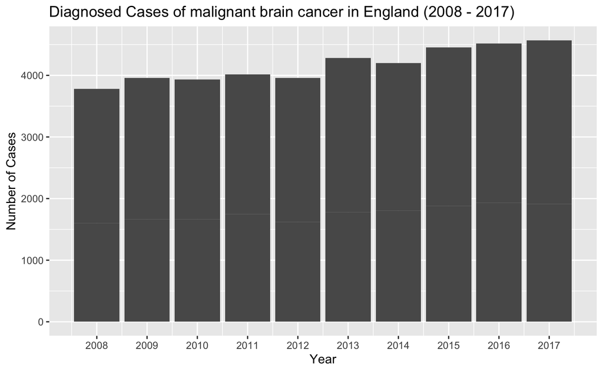

```r
#This data is only for malignant brain tumours. For this reason the comparison graph below for Scotland is also only showing recorded malignant brain tumours.
england_newly_diagnosed_cases %>%
  group_by(year, gender) %>%
  summarise(total = sum(raw_cases)) %>%
  ggplot(aes(year, total)) +
  geom_col() +
  scale_x_continuous(breaks = seq(2008, 2017, by = 1)) +
  ggtitle("Diagnosed Cases of malignant brain cancer in England (2008 - 2017)") +
  xlab("Year") +
  ylab("Number of Cases")
```

Plotting the same graph but for Scottish data to see how the two compare.

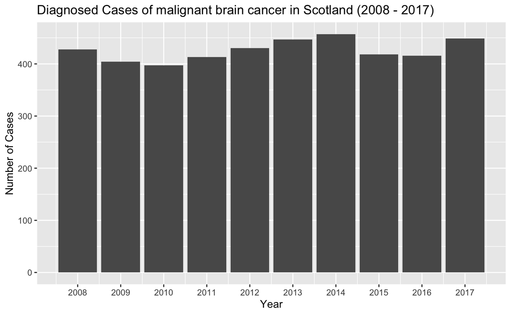

```r
scotland_incidences_all_ages <- incidences %>%
  filter(hb_label == "SCOTLAND") %>%
  filter(age_label == "Number of registrations: All Ages") %>%
  filter(site_label == "Malignant brain cancer") %>%
  filter(sex_label == "All Persons") %>%
  filter(year > 2007)

scotland_incidences_all_ages %>%
  ggplot(aes(year, incidence_no_and_rates)) +
  geom_col() +
  scale_x_continuous(breaks = seq(2008, 2017, by = 1)) +
  ggtitle("Diagnosed Cases of malignant brain cancer in Scotland (2008 - 2017)") +
  xlab("Year") +
  ylab("Number of Cases")
```

# Daily Cases

https://beta.isdscotland.org/find-publications-and-data/conditions-and-diseases/cancer/cancer-incidence-in-scotland/28-april-2020/

Identifying the number of cases diagnosed each day from 1994 to 2018. This includes all three brain cancer types specified in the data (Malignant Brain Cancer, Malignant Brain Cancer including the pituitary gland, craniopharyngeal duct and pineal gland and Non Malignant cancer including the pituitary gland, craniopharyngeal duct and pineal gland).

I decided to find the mean number of incidences of non-malignant brain tumours in order to impute the missing values with it. According to Wu, Khorshidi, Aickelin, Edib and Peate (2019), simple mean mutation is a better method of handling missing values than deletion when dealing with breast cancer data. https://link.springer.com/article/10.1007/s13755-019-0082-4

```r
updated_cancer_incidences %>%
  filter(hb_label == "SCOTLAND") %>%
  filter(age_label == "Number of registrations: All Ages") %>%
  filter(site_label == "Non-malignant brain cancer (incl pituitary gland, craniopharyngeal duct and pineal gland)") %>%
  filter(sex_label == "All Persons") %>%
  drop_na() %>%
  summarise(mean_incidence = mean(incidence_no_and_rates))
```

| mean_incidence |
| --- |
| 534 |

```r
#Filtering out malignant brain cancer and total cancer cases because I am trying to ascertain if the malignant brain cancer including pituitary gland etc and non-malignant brain cancer including the pituitary gland etc combine to make the same total as the all brain and CNS tumours incidence column.
scotland_incidences_all_types <- updated_cancer_incidences %>%
  filter(hb_label == "SCOTLAND") %>%
  filter(age_label == "Number of registrations: All Ages") %>%
  filter(sex_label == "All Persons") %>%
  filter(site_label != "Malignant brain cancer") %>%
  filter(site_label != "All brain and CNS tumours (malignant and non-malignant)") %>%
  mutate(incidence_no_and_rates = coalesce(incidence_no_and_rates, 534, na.rm = TRUE))
```

The total number of cases of malignant and non-malignant brain tumours including those in the pituitary gland, craniopharyngeal duct and pineal gland is the same as the total number of tumours found in the brain and central nervous system data. However, it was necessary to identify the total number of cases by hand in order to impute the missing values from 1994 to 1999 in the non-malignant cancer data with the mean. The data for total tumours for those years was missing and so had to be calculated as above.

[figure not shown]

```r
scotland_incidences_all_types %>%
  group_by(year) %>%
  summarise(total_cases = sum(incidence_no_and_rates)) %>%
  mutate(avg_diagnosed_per_day = total_cases / 365) %>%
  ggplot(aes(year, avg_diagnosed_per_day)) +
  geom_point() +
  geom_smooth(se = FALSE, color = "firebrick3") +
  scale_x_continuous(breaks = seq(1994, 2018, by = 1)) +
  labs(title = "Estimated Daily Diagnosis in Scotland from 1993 to 2017",
       subtitle = "Malignant and non-malignant brain tumours") +
  theme(axis.text.x = element_text(angle = 45, hjust = 0.9)) +
  xlab("Year of Diagnosis") +
  ylab("Estimated New Cases Each Day")
```

# Percentage of the Scottish population

As of mid 2018, the Scottish population was 5,438,100 (National Records of Scotland, https://www.nrscotland.gov.uk/files/statistics/rgar/2018/rgar18.pdf). The number of cases diagnosed in 2018 was 966.

```r
updated_cancer_incidences %>%
  filter(hb_label == "SCOTLAND") %>%
  filter(age_label == "Number of registrations: All Ages") %>%
  filter(sex_label == "All Persons") %>%
  filter(site_label == "All brain and CNS tumours (malignant and non-malignant)") %>%
  filter(year == 2018)
```

| hb_label | site_label | sex_label | age_label | year | incidence_no_and_rates |
| --- | --- | --- | --- | --- | --- |
| SCOTLAND | All brain and CNS tumours (malignant and non-malignant) | All Persons | Number of registrations: All Ages | 2018 | 966 |

```r
updated_cancer_incidences %>%
  filter(hb_label == "SCOTLAND") %>%
  filter(age_label == "Number of registrations: All Ages") %>%
  filter(sex_label == "All Persons") %>%
  filter(site_label == "All brain and CNS tumours (malignant and non-malignant)") %>%
  filter(year == 2000)
```

| hb_label | site_label | sex_label | age_label | year | incidence_no_and_rates |
| --- | --- | --- | --- | --- | --- |
| SCOTLAND | All brain and CNS tumours (malignant and non-malignant) | All Persons | Number of registrations: All Ages | 2000 | 807 |

```r
966 / 5438100 * 100
```

```
[1] 0.01776356
```

```r
807 / 5067000 * 100
```

```
[1] 0.01592658
```

# Age Demographic Cancer Incidence

```r
updated_cancer_incidences %>%
  filter(age_label == "Number of registrations: Under 5" | age_label ==  "Number of registrations: 5.." | age_label == "Number of registrations: 10-14" | age_label ==  "Number of registrations: 15-19" | age_label == "Number of registrations: 20-24" | age_label ==  "Number of registrations: 25-29" | age_label == "Number of registrations: 30-34" | age_label ==  "Number of registrations: 35-39"| age_label ==  "Number of registrations: 40-44" | age_label ==  "Number of registrations: 45-49" | age_label ==  "Number of registrations: 50-54" | age_label ==  "Number of registrations: 55-59" | age_label ==  "Number of registrations: 60-64" | age_label == "Number of registrations: 65-69" | age_label ==  "Number of registrations: 70-74" | age_label == "Number of registrations: 75-79" | age_label == "Number of registrations: 80x4" | age_label ==  "Number of registrations: 85x9" | age_label ==  "Number of registrations: 90+") %>%
  filter(sex_label == "All Persons") %>%
  filter(hb_label == "SCOTLAND") %>%
  filter(site_label == "All brain and CNS tumours (malignant and non-malignant)") %>%
  filter(year > 2008) %>%
  arrange(year)
```

| hb_label | site_label | sex_label | age_label | year | incidence_no_and_rates |
| --- | --- | --- | --- | --- | --- |
| SCOTLAND | All brain and CNS tumours (malignant and non-malignant) | All Persons | Number of registrations: Under 5 | 2009 | 14 |
| SCOTLAND | All brain and CNS tumours (malignant and non-malignant) | All Persons | Number of registrations: 5.. | 2009 | 10 |
| SCOTLAND | All brain and CNS tumours (malignant and non-malignant) | All Persons | Number of registrations: 10-14 | 2009 | 15 |
| SCOTLAND | All brain and CNS tumours (malignant and non-malignant) | All Persons | Number of registrations: 15-19 | 2009 | 16 |
| SCOTLAND | All brain and CNS tumours (malignant and non-malignant) | All Persons | Number of registrations: 20-24 | 2009 | 13 |
| SCOTLAND | All brain and CNS tumours (malignant and non-malignant) | All Persons | Number of registrations: 25-29 | 2009 | 37 |
| SCOTLAND | All brain and CNS tumours (malignant and non-malignant) | All Persons | Number of registrations: 30-34 | 2009 | 29 |
| SCOTLAND | All brain and CNS tumours (malignant and non-malignant) | All Persons | Number of registrations: 35-39 | 2009 | 38 |
| SCOTLAND | All brain and CNS tumours (malignant and non-malignant) | All Persons | Number of registrations: 40-44 | 2009 | 55 |
| SCOTLAND | All brain and CNS tumours (malignant and non-malignant) | All Persons | Number of registrations: 45-49 | 2009 | 66 |

[output cut: 180 more lines]

# Survival

Net survival is an estimate of the probability that the average patient will be alive at a given time after diagnosis, after controlling for other causes of death.

£15038718 spent on Brain cancer research in 2018/2019 (6.55%) £35439980 spent on Leukaemia research in 2018/2019 (15.43%)

In 2012/2013, only £6 million was spent on Brain cancer research. The allocated budget for brain tumour research is growing, but there is still a bridge to gap between this region and research into other cancers. This may be an important factor in reducing the preventable deaths that still occur for those diagnosed with a brain tumour.

```
Problem with `mutate()` input `net_survival_percent`.
ℹ NAs introduced by coercion
ℹ Input `net_survival_percent` is `as.double(net_survival_percent)`.NAs introduced by coercion
```

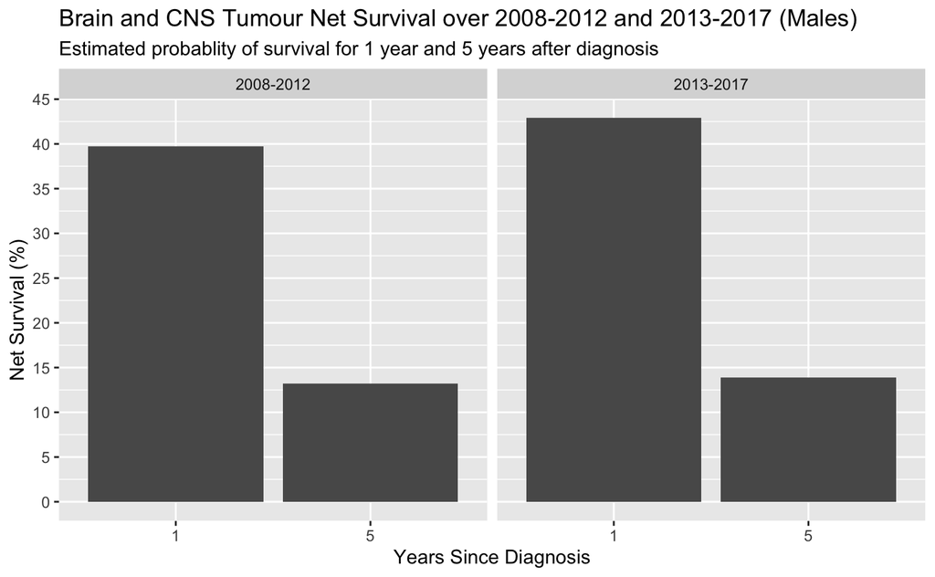

```r
#Net survival of males aged from 15 to 99 at 1 and 5 years after the diagnosis.
survival_data %>%
  select(calendar_period_of_diagnosis, sex, age_group, years_since_diagnosis,
         net_survival_percent) %>%
  mutate(net_survival_percent = as.double(net_survival_percent)) %>%
  mutate(years_since_diagnosis = as.factor(years_since_diagnosis)) %>%
  filter(sex == "Male") %>%
  filter(calendar_period_of_diagnosis == "2013-2017" |
            calendar_period_of_diagnosis == "2008-2012") %>%
  filter(age_group == "15-99") %>%
  filter(years_since_diagnosis != 10) %>%
  ggplot(aes(years_since_diagnosis, net_survival_percent)) +
  geom_col() +
  facet_wrap(~ calendar_period_of_diagnosis) +
  labs(title = "Brain and CNS Tumour Net Survival over 2008-2012 and 2013-2017 (Males)",
       subtitle = "Estimated probablity of survival for 1 year and 5 years after diagnosis") +
  xlab("Years Since Diagnosis") +
  ylab("Net Survival (%)") +
  scale_y_continuous(breaks = seq(0, 50, by = 5))
```

```
Problem with `mutate()` input `net_survival_percent`.
ℹ NAs introduced by coercion
ℹ Input `net_survival_percent` is `as.double(net_survival_percent)`.NAs introduced by coercion
```

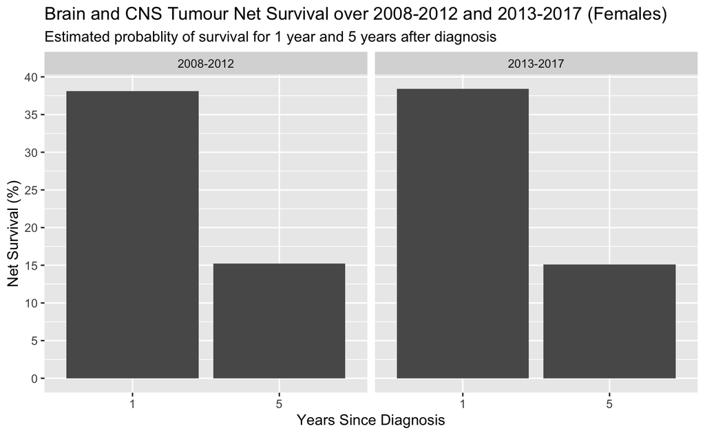

```r
#Net survival of females aged from 15 to 99 at 1 and 5 years after the diagnosis.
survival_data %>%
  select(calendar_period_of_diagnosis, sex, age_group, years_since_diagnosis, net_survival_percent) %>%
  mutate(net_survival_percent = as.double(net_survival_percent)) %>%
  mutate(years_since_diagnosis = as.factor(years_since_diagnosis)) %>%
  filter(sex == "Female") %>%
  filter(calendar_period_of_diagnosis == "2013-2017" |
            calendar_period_of_diagnosis == "2008-2012") %>%
  filter(age_group == "15-99") %>%
  filter(years_since_diagnosis != 10) %>%
  ggplot(aes(years_since_diagnosis, net_survival_percent)) +
  geom_col() +
  facet_wrap(~ calendar_period_of_diagnosis) +
  labs(title = "Brain and CNS Tumour Net Survival over 2008-2012 and 2013-2017 (Females)",
       subtitle = "Estimated probablity of survival for 1 year and 5 years after diagnosis") +
  xlab("Years Since Diagnosis") +
  ylab("Net Survival (%)") +
  scale_y_continuous(breaks = seq(0, 50, by = 5))
```

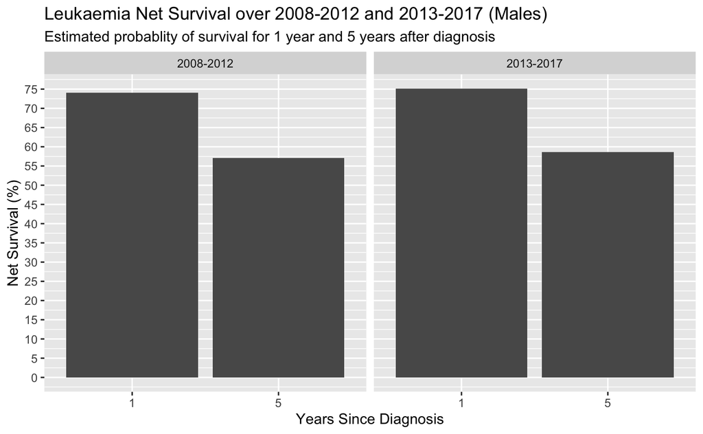

```r
survival_leukaemia_clean %>%
  select(calendar_period_of_diagnosis, sex, age_group, years_since_diagnosis,
         net_survival_percent) %>%
  mutate(net_survival_percent = as.double(net_survival_percent)) %>%
  mutate(years_since_diagnosis = as.factor(years_since_diagnosis)) %>%
  filter(sex == "Male") %>%
  filter(calendar_period_of_diagnosis == "2013-2017" |
            calendar_period_of_diagnosis == "2008-2012") %>%
  filter(age_group == "15-99") %>%
  filter(years_since_diagnosis != 10) %>%
  ggplot(aes(years_since_diagnosis, net_survival_percent)) +
  geom_col() +
  facet_wrap(~ calendar_period_of_diagnosis) +
  labs(title = "Leukaemia Net Survival over 2008-2012 and 2013-2017 (Males)",
       subtitle = "Estimated probablity of survival for 1 year and 5 years after diagnosis") +
  xlab("Years Since Diagnosis") +
  ylab("Net Survival (%)") +
  scale_y_continuous(breaks = seq(0, 85, by = 5))
```

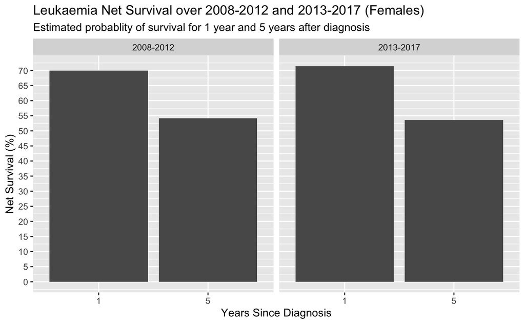

```r
survival_leukaemia_clean %>%
  select(calendar_period_of_diagnosis, sex, age_group, years_since_diagnosis,
         net_survival_percent) %>%
  mutate(net_survival_percent = as.double(net_survival_percent)) %>%
  mutate(years_since_diagnosis = as.factor(years_since_diagnosis)) %>%
  filter(sex == "Female") %>%
  filter(calendar_period_of_diagnosis == "2013-2017" |
            calendar_period_of_diagnosis == "2008-2012") %>%
  filter(age_group == "15-99") %>%
  filter(years_since_diagnosis != 10) %>%
  ggplot(aes(years_since_diagnosis, net_survival_percent)) +
  geom_col() +
  facet_wrap(~ calendar_period_of_diagnosis) +
  labs(title = "Leukaemia Net Survival over 2008-2012 and 2013-2017 (Females)",
       subtitle = "Estimated probablity of survival for 1 year and 5 years after diagnosis") +
  xlab("Years Since Diagnosis") +
  ylab("Net Survival (%)") +
  scale_y_continuous(breaks = seq(0, 85, by = 5))
```

There was missing data in the 10 year survival rates of brain tumours, however there is data for the number of deaths within 10 years of a diagnosis of brain cancer. The number of deaths decreased slightly in the 2013-2017 grouping when compared to the 2008-2012 grouping, suggesting more people are surviving brain cancer for longer. This graph also indicates the number of deaths within 10 years occur mostly within those aged over 54.

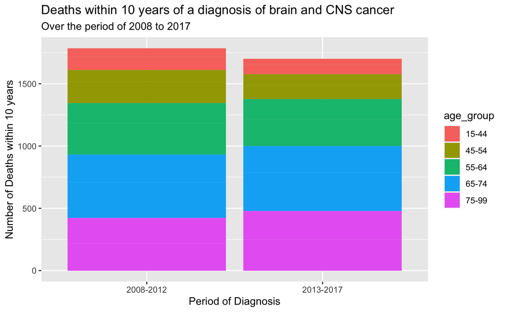

```r
#Deaths within 10 years
survival_data %>%
  select(sex, age_group, years_since_diagnosis, deaths_within_10_years, calendar_period_of_diagnosis) %>%
  filter(years_since_diagnosis == 1) %>%
  filter(calendar_period_of_diagnosis == "2008-2012"
         | calendar_period_of_diagnosis ==  "2013-2017") %>%
  filter(age_group == "15-44" | age_group == "45-54" | age_group == "55-64" |
          age_group == "65-74" | age_group == "75-99") %>%
  ggplot(aes(calendar_period_of_diagnosis, deaths_within_10_years, fill = age_group)) +
  geom_col() +
  labs(title = "Deaths within 10 years of a diagnosis of brain and CNS cancer",
       subtitle = "Over the period of 2008 to 2017") +
  xlab("Period of Diagnosis") +
  ylab("Number of Deaths within 10 years")
```

# Mortality

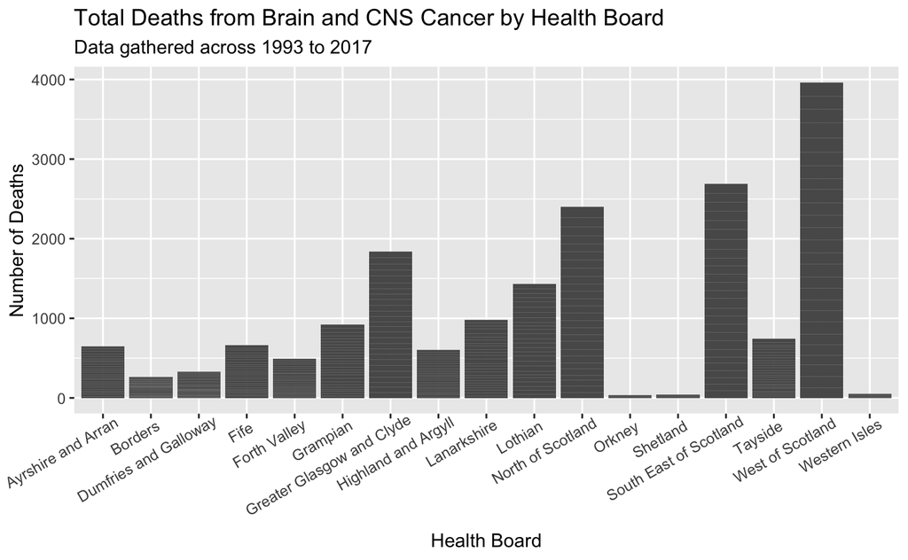

```r
mortality %>%
  filter(site_label == "Malignant brain cancer (incl pituitary gland, craniopharyngeal duct and pineal gland)") %>%
  filter(sex_label == "All Persons") %>%
  filter(age_label == "Number of deaths: All Ages") %>%
  filter(hb_label != "SCOTLAND") %>%
  ggplot(aes(hb_label, incidence_no_and_rates)) +
  geom_col() +
  labs(title = "Total Deaths from Brain and CNS Cancer by Health Board",
       subtitle = "Data gathered across 1993 to 2017") +
  xlab("Health Board") +
  ylab("Number of Deaths") +
  theme(axis.text.x = element_text(angle = 30, hjust = 0.9))
```